# Stock Price Project

# The idea

I want to try and practice my Machine Learning skills on financial data To do so, I wanted to try and use a dataset of 100 variables to predict some stock prices. I thought of trying to predict medical/Agri stocks, so I chose:

1. TEVA [TEVA]
2. Bayer [BAYRY]
3. Pfizer [PFE]
4. Protalyx [PLX]
5. Kamada [KMDA]

Don’t use because they’re either private or owned by something bigger: Netafim, ADAMA

I thought of using these parameters: Dollar, Euro, Shekel prices Major stock market indicators: NASDAQ Specific stocks like “top-30 pharma” Weather indicators like amount of rain in NYC (this is to see if it will be excluded)

# Notes and tips from Ran:

- Maybe start with something less chaotic than stocks. Stocks like TEVA are affected by human elements like a CEO descision or a flop product or a scandal.
- Try and predict oil or cotton prices. if you can do that you could be pretty rich
- Anything you try will always be difficult to predict, FYI
- I thought about doing something like extreme weather to predict oil. Let’s say you have a draught and that causes oil demand to peak (for some unknown reason), you can then predict the next draught and go into oil and make a bundle in a year (or fail miserably).
- Keep in mind, good data is hard to get. stocks, currency and weather are easy to google

# Targets to predict

I want to try and predict, looking only up to Jan 2019, what will be the stock prices of the 5 companies over the course of 3 months of 2019. So my predictions will try and project: closing Stock prices, per week (thursday), for 15 weeks for the following 5 companies:

1. TEVA [TEVA]
2. Bayer [BAYRY]
3. Pfizer [PFE]
4. Protalyx [PLX]
5. Kamada [KMDA]

# Input data

For this, I want to choose 100 parameters. they may have completely differnt scales but all must change over TIME.

| n | Data | # of parameters |
| --- | --- | --- |
| 1 | Historical data for all companies up to and including December 2018 | 5 |
| 2 | Currency goods prices for dollars, Euro, Shekels, Yen | 3 |
| 3 | Goods prices: Oil, Gold, Cotton, Corn, roses | 5 |
| 4 | Competitor prices for Gilead, Novartis, Monsanto, |  |

# Test run on loading data

## date: 20/04/2020

I collected these elements from the web: Index data from https://us.spindices.com/indices Specific stock prices from Yahoo finance.

I have: indices:

```r
list.files("C:/Users/anakar/Desktop/Scratchboard/Stock prices/Input Data/Indices")
```

```
## [1] "DJISCI - Dow Jones Israel Select Consumer Index.xls"
## [2] "DJISHI - Dow Jones Israel Select Health Care Index.xls"
## [3] "DJISOI - Dow Jones Israel Select Oil & Gas Index.xls"
## [4] "DJUSCI - Dow Jones U.S. Coal Index (USD).xls"
## [5] "DJUSI - Dow Jones U.S. Index.xls"
## [6] "SPPSI - S&P Pharmaceuticals Select Industry Index.xls"
```

Stocks:

```r
list.files("C:/Users/anakar/Desktop/Scratchboard/Stock prices/Input Data/competitors")
```

```
## [1] "Galaxosmith-GLX.csv" "Novartis-NVS.csv"    "ProtalixPLX.csv"
```

```r
list.files("C:/Users/anakar/Desktop/Scratchboard/Stock prices/Input Data/target firms")
```

```
## [1] "Bayer-BAYRY.csv" "TEVA.csv"
```

So all in all I have:

```
## [1] 11
```

### Importing the data

I’ll start with the indices Their structure is .xls files, where the info starts at row 8, and I want only columns A and C (date and Consumer index)

This is what I wrote today:

The first one is only for the Dow Jones U.S. Index

```r
#### Importing Xls files #######

library("readxl")
library(ggplot2)

#This imports just the first one, as a test.

dow_jones = as.data.frame(read_xls    # To import file
                          ("C:/Users/anakar/Desktop/Scratchboard/Stock prices/Input Data/Indices/DJUSI - Dow Jones U.S. Index.xls",
                            range = "A8:C5000", col_names = F))
```

```
## * `` -> ...1
## * `` -> ...2
## * `` -> ...3
```

```r
dow_jones[,2] = NULL                        # to delete the not-needed column
colnames(dow_jones) = c("Date", "index")    # changes col names
head(dow_jones)                             # a look at the product
```

|  | Date | index |
| --- | --- | --- |
| 1 | 2010-03-31 | 291.23 |
| 2 | 2010-04-01 | 293.49 |
| 3 | 2010-04-02 | 293.49 |
| 4 | 2010-04-03 | 293.49 |
| 5 | 2010-04-04 | 293.49 |
| 6 | 2010-04-05 | 296.20 |

```r
dim(dow_jones)
```

```
## [1] 4993    2
```

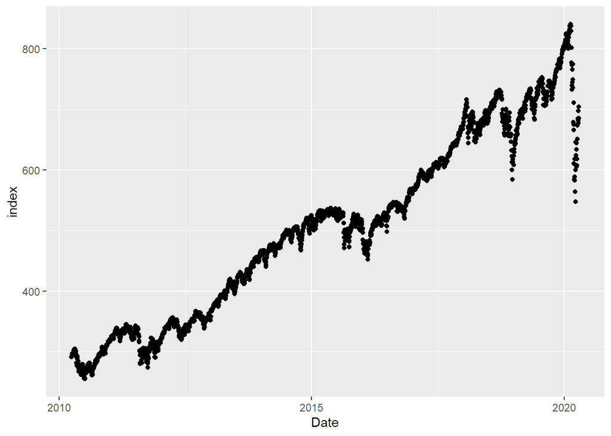

```r
dow_jones_plot = ggplot(dow_jones,aes(x=Date,y=index)) + geom_point()

dow_jones_plot
```

And now to plot all 6 indices

```
## [1] "DJISCI - Dow Jones Israel Select Consumer Index.xls"
## [2] "DJISHI - Dow Jones Israel Select Health Care Index.xls"
## [3] "DJISOI - Dow Jones Israel Select Oil & Gas Index.xls"
## [4] "DJUSCI - Dow Jones U.S. Coal Index (USD).xls"
## [5] "DJUSI - Dow Jones U.S. Index.xls"
## [6] "SPPSI - S&P Pharmaceuticals Select Industry Index.xls"
```

```
## * `` -> ...1
## * `` -> ...2
## * `` -> ...3
```

```
## * `` -> ...1
## * `` -> ...2
## * `` -> ...3
```

```
## * `` -> ...1
## * `` -> ...2
## * `` -> ...3
```

```
## * `` -> ...1
## * `` -> ...2
## * `` -> ...3
```

```
## * `` -> ...1
## * `` -> ...2
## * `` -> ...3
```

```
## * `` -> ...1
## * `` -> ...2
## * `` -> ...3
```

|  | Date | index | file |
| --- | --- | --- | --- |
| 1 | 2010-03-31 | 291.23 | test |
| 2 | 2010-04-01 | 293.49 | test |
| 3 | 2010-04-02 | 293.49 | test |
| 4 | 2010-04-03 | 293.49 | test |
| 5 | 2010-04-04 | 293.49 | test |
| 6 | 2010-04-05 | 296.20 | test |

```
## [1] 34951     3
```

```
## [1] 4993    2
```

```
## [1] "DJISCI - Dow Jones Israel Select Consumer Index.xls"
## [2] "DJISHI - Dow Jones Israel Select Health Care Index.xls"
## [3] "DJISOI - Dow Jones Israel Select Oil & Gas Index.xls"
## [4] "DJUSCI - Dow Jones U.S. Coal Index (USD).xls"
## [5] "DJUSI - Dow Jones U.S. Index.xls"
## [6] "SPPSI - S&P Pharmaceuticals Select Industry Index.xls"
## [7] "test"
```

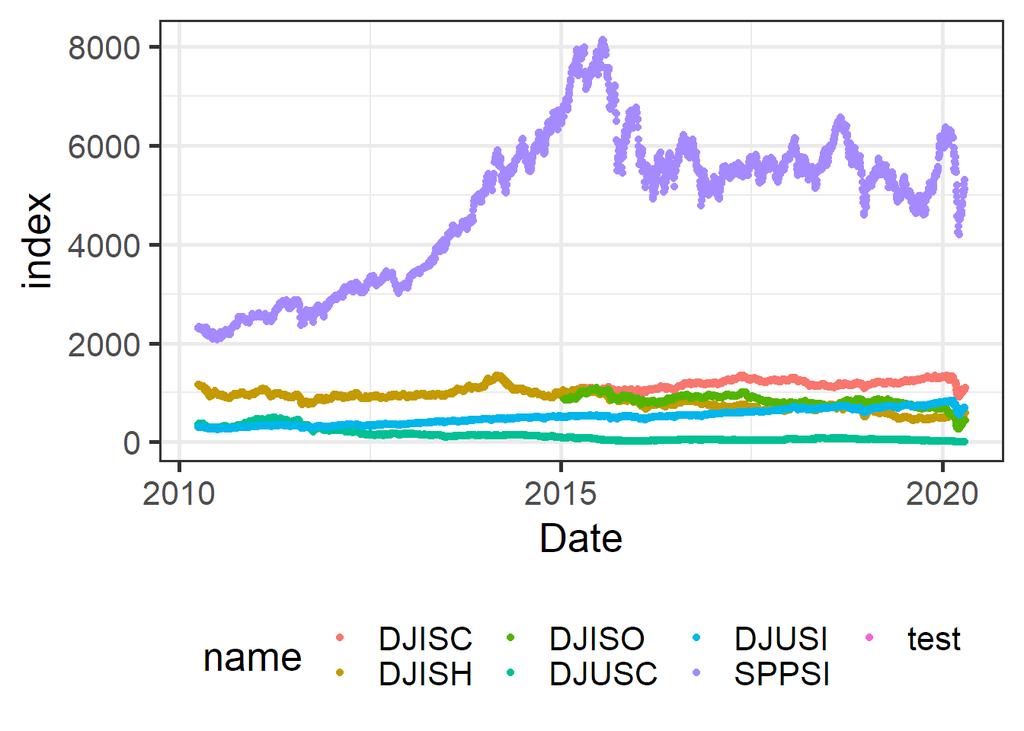

## Date: 20/04/21

starting 15:15

What I want to do: 0. Find goods data 1. take out the “test” data in the index df 2. load the competitors data in

### Find goods data

found it at https://www.indexmundi.com/commodities/?commodity=corn&months=120 Downloaded: Food: Corn, Tea, Rice, Beef Industrial: Oil, Gold, Aluminum

### Taking out the “test” data in the index df

Updated R [like this](https://www.linkedin.com/pulse/3-methods-update-r-rstudio-windows-mac-woratana-ngarmtrakulchol/)

Vered woke up, and I was with her for 20 mins

```r
### To take out the rows which are called "test" I want to make a vector of them and then nullify in df.

test.vector = df$file == "test"    #This creates a true/false vector for the rows with "test"
summary(test.vector)               # QC: to see the number of rows to be deleted
```

```
##    Mode   FALSE    TRUE
## logical   29958    4993
```

```r
dim(dow_jones)                     # QC: the number of rows in the original dow jones file
```

```
## [1] 4993    2
```

```r
df.clean = df[!test.vector, ]

dim(dow_jones)+dim(df.clean) == dim(df)   #QC before gettting rid of the old rows
```

```
## [1]  TRUE FALSE
```

```r
df = df.clean
```

### Load the competitors data in

I first will look at the data themselves. Much nicer! * .CSV files * 7 columns, but I only want the date and closing, so 1 and 5 let’s start:

```r
#### Importing competitor files #######


#This imports just the first one, as a test.

comp.stock = read.csv("C:/Users/anakar/Desktop/Scratchboard/Stock prices/Input Data/Competitors/Galaxosmith-GLX.csv", header = T)[,c(1,5)]


head(comp.stock)                             # a look at the product
```

|  | Date | Close |
| --- | --- | --- |
| 1 | 2015-04-20 | 47.10 |
| 2 | 2015-04-21 | 47.24 |
| 3 | 2015-04-22 | 46.57 |
| 4 | 2015-04-23 | 46.31 |
| 5 | 2015-04-24 | 46.59 |
| 6 | 2015-04-27 | 46.85 |

```r
colnames(comp.stock)
```

```
## [1] "Date"  "Close"
```

```r
dim(comp.stock)
```

```
## [1] 1259    2
```

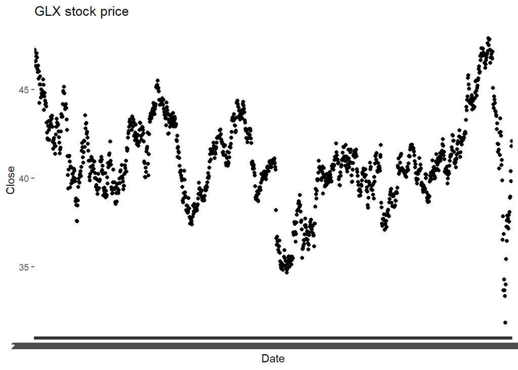

```r
GLX_plot = ggplot(comp.stock,aes(x=Date,y=Close)) + geom_point() + labs(title="GLX stock price")

GLX_plot
```

This doesn’t look right… let me check in excel if it looks different. Okay I checked. It’s correct.

now to get them all in:

```r
#Now to get all 3 competitors

comp.stock.path = "C:/Users/anakar/Desktop/Scratchboard/Stock prices/Input Data/Competitors"
comp.stock.files = list.files(comp.stock.path)

comp.stock.files
```

```
## [1] "Galaxosmith-GLX.csv" "Novartis-NVS.csv"    "ProtalixPLX.csv"
```

```r
comp.stock.df = comp.stock
comp.stock.df$stock = "GSK"

head(comp.stock.df)
```

|  | Date | Close | stock |
| --- | --- | --- | --- |
| 1 | 2015-04-20 | 47.10 | GSK |
| 2 | 2015-04-21 | 47.24 | GSK |
| 3 | 2015-04-22 | 46.57 | GSK |
| 4 | 2015-04-23 | 46.31 | GSK |
| 5 | 2015-04-24 | 46.59 | GSK |
| 6 | 2015-04-27 | 46.85 | GSK |

```r
for(i in 1:length(comp.stock.files)) {
        filename = comp.stock.files[i]
        file = paste(comp.stock.path, filename, sep = "/")
        read = read.csv(file, header = T)[,c(1,5)]

        read$stock = filename
        comp.stock.df = rbind(comp.stock.df,read)
}

#This is just a quality control
      head(comp.stock.df)
```

|  | Date | Close | stock |
| --- | --- | --- | --- |
| 1 | 2015-04-20 | 47.10 | GSK |
| 2 | 2015-04-21 | 47.24 | GSK |
| 3 | 2015-04-22 | 46.57 | GSK |
| 4 | 2015-04-23 | 46.31 | GSK |
| 5 | 2015-04-24 | 46.59 | GSK |
| 6 | 2015-04-27 | 46.85 | GSK |

```r
      dim(comp.stock.df)
```

```
## [1] 5036    3
```

```r
      dim(comp.stock)
```

```
## [1] 1259    2
```

```r
# to make the filenames into categories
comp.stock.df$stock = as.factor(comp.stock.df$stock)
levels(comp.stock.df$stock)
```

```
## [1] "Galaxosmith-GLX.csv" "GSK"                 "Novartis-NVS.csv"
## [4] "ProtalixPLX.csv"
```

```r
#######comp.stock.df$stock = substr(df$file, start = -5, stop = -8)


dim(comp.stock.df)
```

```
## [1] 5036    3
```

```r
head(comp.stock.df)
```

|  | Date | Close | stock |
| --- | --- | --- | --- |
| 1 | 2015-04-20 | 47.10 | GSK |
| 2 | 2015-04-21 | 47.24 | GSK |
| 3 | 2015-04-22 | 46.57 | GSK |
| 4 | 2015-04-23 | 46.31 | GSK |
| 5 | 2015-04-24 | 46.59 | GSK |
| 6 | 2015-04-27 | 46.85 | GSK |

```r
class(comp.stock.df)
```

```
## [1] "data.frame"
```

```r
levels(comp.stock.df$stock)
```

```
## [1] "Galaxosmith-GLX.csv" "GSK"                 "Novartis-NVS.csv"
## [4] "ProtalixPLX.csv"
```

```r
df = comp.stock.df

levels(df$stock)=c("GSK","GSK2","NVS","PLX")
levels(df$stock)
```

```
## [1] "GSK"  "GSK2" "NVS"  "PLX"
```

```r
# Now let's take out GSK1

takeout = df$stock == "GSK2"
#takeout

df = df[!takeout,]
summary(df$stock)
```

```
##  GSK GSK2  NVS  PLX
## 1259    0 1259 1259
```

```r
summary(df$Close[df$stock == "GSK"])
```

```
##    Min. 1st Qu.  Median    Mean 3rd Qu.    Max.
##   31.85   39.46   40.74   40.91   42.42   47.89
```

```r
df = comp.stock.df
df = df[!takeout,]
summary(df$stock)
```

```
## Galaxosmith-GLX.csv                 GSK    Novartis-NVS.csv     ProtalixPLX.csv
##                1259                   0                1259                1259
```

```r
summary(df$Close[df$stock == "ProtalixPLX.csv"])
```

```
##    Min. 1st Qu.  Median    Mean 3rd Qu.    Max.
##   1.800   4.300   5.900   7.043   8.350  22.400
```

```r
df$Date = as.Date(df$Date, format='%Y-%m-%d')

# Make shorter names
df$filename = df$stock
levels(df$stock) = c("GLS","test", "NVS", "PLX")

# And now plotting
plot.comp.stock = ggplot(df, aes(x=Date, y=Close, col=stock)) + geom_point()

plot.comp.stock.formatted = plot.comp.stock +theme_gray(base_size = 20) + theme(legend.position="right", axis.text.x = element_text(angle = 90)) + scale_x_date(date_labels = "%Y")
comp.stock.df = df
```

So, I’m stopping now. This is not clean but getting there… Updating R screwed up the ggplot somehow… knit and out 16:40

## New day

What do I want to do today? 1. Fix the scale for the last figure - done and put into the old code

```
Alright, I fixed a stupid bug. In the line to read the new files I had a specific file loaded up each time... nevermind, moving forward. Here's the graph:
```

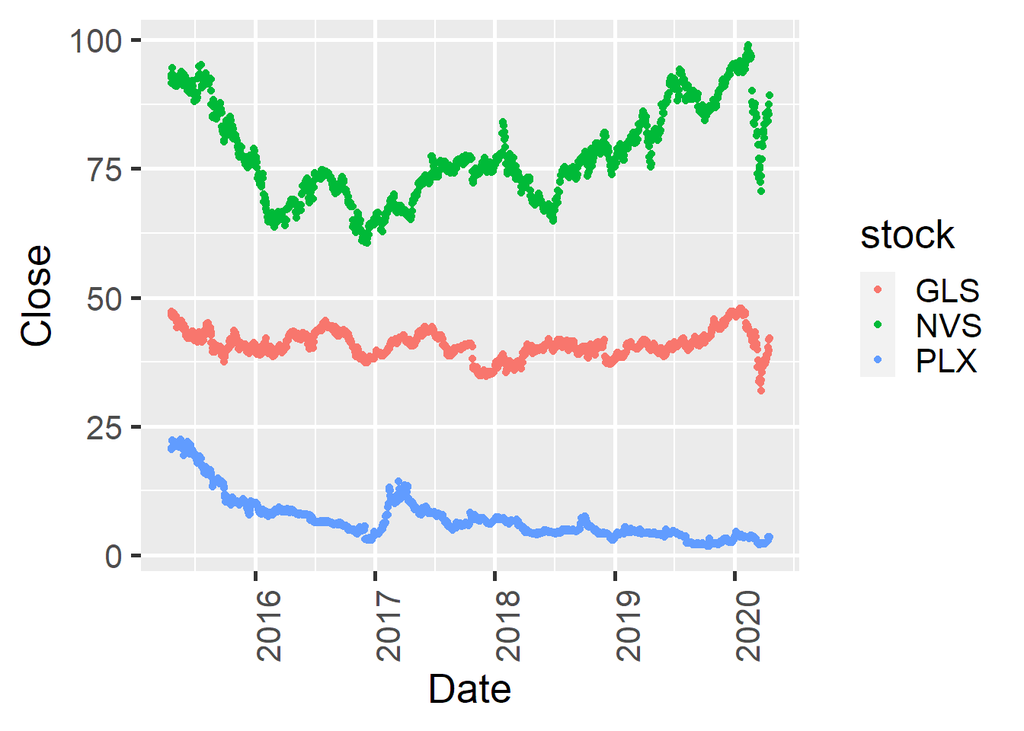

```r
plot.comp.stock.formatted
```

2. make a correlation map so that I can see correlations between different data

Let’s start with the weird formatting and scale from last time

```r
sum.GLS = summary(df$Close[df$stock == "GLS"])
sum.NVS = summary(df$Close[df$stock == "NVS"])
sum.PLX = summary(df$Close[df$stock == "PLX"])

stock.GLS = df$Close[df$stock == "GLS"]
stock.NVS = df$Close[df$stock == "NVS"]
stock.PLX = df$Close[df$stock == "PLX"]
print(sum.GLS)
```

```
##    Min. 1st Qu.  Median    Mean 3rd Qu.    Max.
##   31.85   39.46   40.74   40.91   42.42   47.89
```

```r
print(sum.NVS)
```

```
##    Min. 1st Qu.  Median    Mean 3rd Qu.    Max.
##   60.56   70.96   76.14   77.67   84.99   99.01
```

```r
print(sum.PLX)
```

```
##    Min. 1st Qu.  Median    Mean 3rd Qu.    Max.
##   1.800   4.300   5.900   7.043   8.350  22.400
```

```r
class(df$Close[df$stock == "GLS"])
```

```
## [1] "numeric"
```

```r
cor(stock.GLS,stock.NVS)
```

```
## [1] 0.4078177
```

```r
closing = data.frame(cbind(stock.GLS, stock.NVS,stock.PLX))

dim(closing)
```

```
## [1] 1259    3
```

```r
colnames(closing)
```

```
## [1] "stock.GLS" "stock.NVS" "stock.PLX"
```

```r
cor.matrix = cor(closing)
```

Now to make it into a heatmap:

```r
    if (!requireNamespace("BiocManager", quietly = TRUE))
            install.packages("BiocManager")
    BiocManager::install()
```

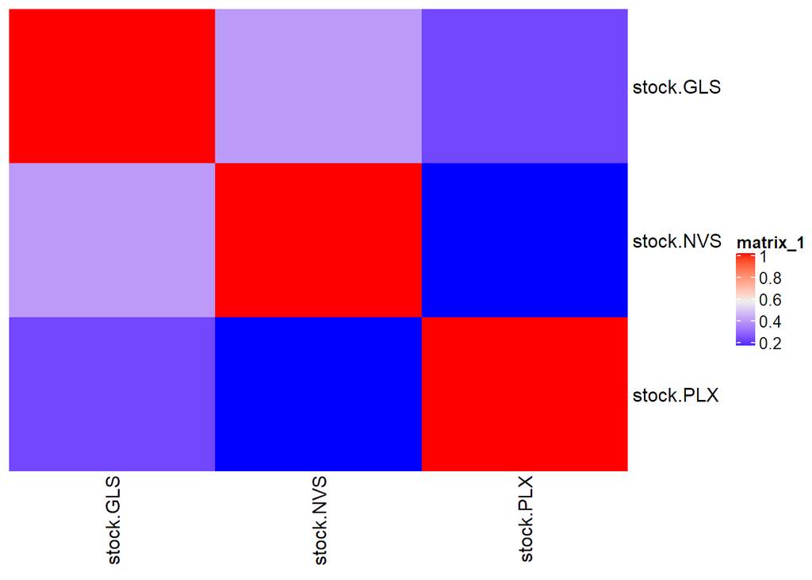

```r
    BiocManager::install(c("ComplexHeatmap", "AnnotationDbi"))
    library(ComplexHeatmap)
Heatmap(cor.matrix,
        cluster_columns=FALSE,
        cluster_rows=FALSE
)
```

So - I finished what I wanted. This took ~1.5 hours but looks nice, no? Knit.